# Final Project

### Remove codes column

```r
nyc_data <- nyc_data[, -which(names(nyc_data) ==    "ICD10.Code.s.")]
nyc_data
```

```
##                                            Cause.of.Death   Total    Total.1
## 1                                          Cause of Death  Number Crude Rate
## 2                                                   Total 181,421      913.6
## 3                                            Tuberculosis      34        0.2
## 4                                              Septicemia   2,241       11.3
## 5              Acquired Immune Deficiency Syndrome (AIDS)     405        2.0
## 6                                     Malignant Neoplasms  32,464      163.5
## 7                               Buccal Cavity and Pharynx     556        2.8
## 8                         Digestive Organs and Peritoneum   9,248       46.6
## 9                                      Respiratory System   7,060       35.6
## 10                             Trachea, Bronchus and Lung   6,806       34.3
## 11                                                   Skin     563        2.8
## 12                                                 Breast   2,303       11.6
## 13                                         Genital Organs   3,671       18.5
## 14                                         Urinary Organs   1,548        7.8
```

[output cut: 141 more lines]

### Rename the columns for better understanding

```r
colnames(nyc_data)[1] = "Causes_Death"
colnames(nyc_data)[2] = "Total_Number"
colnames(nyc_data)[3] = "Crud_Rate"
colnames(nyc_data)[4] = "Adjusted_Rate"
colnames(nyc_data)[5] = "White_Total"
colnames(nyc_data)[6] = "White_Crude_Rate"
colnames(nyc_data)[7] = "White_Adjusted_Rate"
colnames(nyc_data)[8] = "Black_Total"
colnames(nyc_data)[9] = "Black_Crude_Rate"
colnames(nyc_data)[10] = "Black_Adjusted_Rate"
nyc_data %>%
   kbl() %>%
  kable_styling(full_width = F)
```

| Causes_Death | Total_Number | Crud_Rate | Adjusted_Rate | White_Total | White_Crude_Rate | White_Adjusted_Rate | Black_Total | Black_Crude_Rate | Black_Adjusted_Rate |
| --- | --- | --- | --- | --- | --- | --- | --- | --- | --- |
| Cause of Death | Number | Crude Rate | Adjusted Rate | Number | Crude Rate | Adjusted Rate | Number | Crude Rate | Adjusted Rate |
| Total | 181,421 | 913.6 | 687.0 | 135,117 | 989.6 | 669.5 | 26,707 | 754.1 | 695.6 |
| Tuberculosis | 34 | 0.2 | 0.1 | 12 | 0.1 | 0.1 | 5 | 0.1 | 0.1 |
| Septicemia | 2,241 | 11.3 | 8.4 | 1,585 | 11.6 | 7.7 | 410 | 11.6 | 10.8 |
| Acquired Immune Deficiency Syndrome (AIDS) | 405 | 2.0 | 1.7 | 135 | 1.0 | 0.8 | 199 | 5.6 | 5.1 |
| Malignant Neoplasms | 32,464 | 163.5 | 121.1 | 24,768 | 181.4 | 122.1 | 4,231 | 119.5 | 106.1 |
| Buccal Cavity and Pharynx | 556 | 2.8 | 2.0 | 409 | 3.0 | 2.0 | 60 | 1.7 | 1.5 |
| Digestive Organs and Peritoneum | 9,248 | 46.6 | 34.5 | 6,762 | 49.5 | 33.4 | 1,273 | 35.9 | 32.1 |
| Respiratory System | 7,060 | 35.6 | 25.9 | 5,628 | 41.2 | 27.3 | 779 | 22.0 | 19.3 |
| Trachea, Bronchus and Lung | 6,806 | 34.3 | 25.0 | 5,444 | 39.9 | 26.5 | 736 | 20.8 | 18.3 |
| Skin | 563 | 2.8 | 2.1 | 530 | 3.9 | 2.6 | 17 | 0.5 | 0.4 |
| Breast | 2,303 | 11.6 | 9.2 | 1,663 | 12.2 | 8.9 | 420 | 11.9 | 10.1 |
| Genital Organs | 3,671 | 18.5 | 13.5 | 2,567 | 18.8 | 12.5 | 712 | 20.1 | 17.8 |
| Urinary Organs | 1,548 | 7.8 | 5.5 | 1,314 | 9.6 | 6.1 | 122 | 3.4 | 3.2 |
| Other and Unspecified Sites | 4,535 | 22.8 | 17.1 | 3,613 | 26.5 | 18.1 | 475 | 13.4 | 11.9 |
| Lymphatic and Hematopoietic Tissues | 2,980 | 15.0 | 11.2 | 2,282 | 16.7 | 11.2 | 373 | 10.5 | 9.7 |
| Diabetes Mellitus | 4,799 | 24.2 | 18.0 | 3,159 | 23.1 | 15.5 | 1,029 | 29.1 | 26.7 |
| Parkinson’s Disease | 1,704 | 8.6 | 6.2 | 1,473 | 10.8 | 6.9 | 92 | 2.6 | 2.5 |
| Alzheimer’s Disease | 3,553 | 17.9 | 12.8 | 2,965 | 21.7 | 13.7 | 324 | 9.1 | 8.7 |
| Diseases of the Circulatory System | 53,393 | 268.9 | 195.1 | 39,561 | 289.8 | 186.9 | 8,498 | 239.9 | 221.0 |
| Diseases of the Heart | 42,243 | 212.7 | 153.9 | 31,521 | 230.9 | 148.4 | 6,597 | 186.3 | 171.3 |
| Acute Rheumatic Fever & Chronic Rheumatic Heart Dis. | 193 | 1.0 | 0.7 | 163 | 1.2 | 0.8 | 15 | 0.4 | 0.4 |
| Hypertension with Heart Disease | 4,946 | 24.9 | 18.3 | 3,281 | 24.0 | 15.6 | 1,172 | 33.1 | 30.5 |
| Acute Myocardial Infarction | 5,263 | 26.5 | 19.3 | 4,173 | 30.6 | 19.9 | 620 | 17.5 | 16.0 |
| Other Ischemic Heart Diseases | 22,446 | 113.0 | 81.0 | 16,263 | 119.1 | 75.8 | 3,624 | 102.3 | 93.9 |
| Diseases of Pulmonary Circulation | 975 | 4.9 | 3.8 | 695 | 5.1 | 3.5 | 195 | 5.5 | 5.2 |
| Other Diseases of the Heart | 8,420 | 42.4 | 30.9 | 6,946 | 50.9 | 32.9 | 971 | 27.4 | 25.4 |
| Hypertension with or without Renal Disease | 2,880 | 14.5 | 10.5 | 1,938 | 14.2 | 9.1 | 616 | 17.4 | 16.1 |
| Cerebrovascular Disease | 6,635 | 33.4 | 24.5 | 4,872 | 35.7 | 23.2 | 1,006 | 28.4 | 26.3 |
| Arteriosclerosis | 259 | 1.3 | 0.9 | 198 | 1.5 | 0.9 | 41 | 1.2 | 1.0 |
| Other Diseases of the Circulatory System | 1,376 | 6.9 | 5.3 | 1,032 | 7.6 | 5.2 | 238 | 6.7 | 6.2 |
| Pneumonia | 3,724 | 18.8 | 13.6 | 2,740 | 20.1 | 13.0 | 537 | 15.2 | 13.9 |
| Influenza | 27 | 0.1 | 0.1 | 22 | 0.2 | 0.1 | 3 | 0.1 | 0.1 |
| Chronic Lower Respiratory Disease (CLRD) | 5,865 | 29.5 | 21.6 | 4,941 | 36.2 | 23.8 | 551 | 15.6 | 13.9 |
| Gastritis, Enteritis, Colitis, Diverticulitis | 293 | 1.5 | 1.1 | 251 | 1.8 | 1.3 | 27 | 0.8 | 0.7 |
| Cirrhosis of Liver | 1,955 | 9.8 | 8.1 | 1,548 | 11.3 | 8.7 | 167 | 4.7 | 4.3 |
| Nephritis, Nephrotic Syndrome, Nephrosis | 2,534 | 12.8 | 9.3 | 1,870 | 13.7 | 8.9 | 450 | 12.7 | 11.6 |
| Complications of Pregnancy, Childbirth, and Puerperium | 72 | 34.3 | . | 30 | 24.3 | . | 27 | 81.7 | . |
| Maternal Causes | 55 | 26.2 | . | 22 | 17.8 | . | 20 | 60.6 | . |
| Congenital Anomalies | 455 | 2.3 | . | 320 | 2.3 | . | 63 | 1.8 | . |
| Certain Conditions Originating in the Perinatal Period | 427 | 2.2 | . | 163 | 1.2 | . | 150 | 4.2 | . |
| Sudden Infant Death Syndrome | 58 | 27.6 | . | 28 | 22.7 | . | 19 | 57.5 | . |
| Accidents (Total) | 10,091 | 50.8 | 46.1 | 6,981 | 51.1 | 45.2 | 1,867 | 52.7 | 49.7 |
| Motor Vehicle | 1,335 | 6.7 | 6.3 | 913 | 6.7 | 6.1 | 211 | 6.0 | 5.9 |
| Drownings | 151 | 0.8 | 0.7 | 93 | 0.7 | 0.6 | 34 | 1.0 | 1.0 |
| Falls | 1,953 | 9.8 | 7.2 | 1,600 | 11.7 | 7.7 | 146 | 4.1 | 3.9 |
| Poisonings | 5,546 | 27.9 | 27.1 | 3,583 | 26.2 | 26.4 | 1,309 | 37.0 | 34.3 |
| Suicide | 1,647 | 8.3 | 7.8 | 1,280 | 9.4 | 8.6 | 122 | 3.4 | 3.5 |
| Homicide and Legal Intervention | 928 | 4.7 | 4.9 | 235 | 1.7 | 1.8 | 571 | 16.1 | 16.7 |
| COVID-19 | 21,598 | 108.8 | 80.2 | 15,009 | 109.9 | 72.7 | 3,177 | 89.7 | 81.6 |
| All Other Causes | 33,154 | 167.0 | 125.0 | 26,041 | 190.7 | 127.4 | 4,188 | 118.3 | 110.5 |

### Remove Commas from numerical Values

```r
nyc_data$Total_Number <- gsub( ",","", nyc_data$Total_Number)
nyc_data$Crud_Rate <- gsub( ",","", nyc_data$Crud_Rate)
nyc_data$Adjusted_Rate <- gsub( ",","", nyc_data$Adjusted_Rate)
nyc_data$White_Total <- gsub( ",","", nyc_data$White_Total)
nyc_data$White_Crude_Rate <- gsub( ",","", nyc_data$White_Crude_Rate)
nyc_data$White_Adjusted_Rate <- gsub( ",","", nyc_data$White_Adjusted_Rate)
nyc_data$Black_Total <- gsub( ",","", nyc_data$Black_Total)
nyc_data$Black_Crude_Rate <- gsub( ",","", nyc_data$Black_Crude_Rate)
nyc_data$Black_Adjusted_Rate <- gsub( ",","", nyc_data$Black_Adjusted_Rate)
nyc_data %>%
   kbl() %>%
  kable_styling(full_width = F)
```

| Causes_Death | Total_Number | Crud_Rate | Adjusted_Rate | White_Total | White_Crude_Rate | White_Adjusted_Rate | Black_Total | Black_Crude_Rate | Black_Adjusted_Rate |
| --- | --- | --- | --- | --- | --- | --- | --- | --- | --- |
| Cause of Death | Number | Crude Rate | Adjusted Rate | Number | Crude Rate | Adjusted Rate | Number | Crude Rate | Adjusted Rate |
| Total | 181421 | 913.6 | 687.0 | 135117 | 989.6 | 669.5 | 26707 | 754.1 | 695.6 |
| Tuberculosis | 34 | 0.2 | 0.1 | 12 | 0.1 | 0.1 | 5 | 0.1 | 0.1 |
| Septicemia | 2241 | 11.3 | 8.4 | 1585 | 11.6 | 7.7 | 410 | 11.6 | 10.8 |
| Acquired Immune Deficiency Syndrome (AIDS) | 405 | 2.0 | 1.7 | 135 | 1.0 | 0.8 | 199 | 5.6 | 5.1 |
| Malignant Neoplasms | 32464 | 163.5 | 121.1 | 24768 | 181.4 | 122.1 | 4231 | 119.5 | 106.1 |
| Buccal Cavity and Pharynx | 556 | 2.8 | 2.0 | 409 | 3.0 | 2.0 | 60 | 1.7 | 1.5 |
| Digestive Organs and Peritoneum | 9248 | 46.6 | 34.5 | 6762 | 49.5 | 33.4 | 1273 | 35.9 | 32.1 |
| Respiratory System | 7060 | 35.6 | 25.9 | 5628 | 41.2 | 27.3 | 779 | 22.0 | 19.3 |
| Trachea, Bronchus and Lung | 6806 | 34.3 | 25.0 | 5444 | 39.9 | 26.5 | 736 | 20.8 | 18.3 |
| Skin | 563 | 2.8 | 2.1 | 530 | 3.9 | 2.6 | 17 | 0.5 | 0.4 |
| Breast | 2303 | 11.6 | 9.2 | 1663 | 12.2 | 8.9 | 420 | 11.9 | 10.1 |
| Genital Organs | 3671 | 18.5 | 13.5 | 2567 | 18.8 | 12.5 | 712 | 20.1 | 17.8 |
| Urinary Organs | 1548 | 7.8 | 5.5 | 1314 | 9.6 | 6.1 | 122 | 3.4 | 3.2 |
| Other and Unspecified Sites | 4535 | 22.8 | 17.1 | 3613 | 26.5 | 18.1 | 475 | 13.4 | 11.9 |
| Lymphatic and Hematopoietic Tissues | 2980 | 15.0 | 11.2 | 2282 | 16.7 | 11.2 | 373 | 10.5 | 9.7 |
| Diabetes Mellitus | 4799 | 24.2 | 18.0 | 3159 | 23.1 | 15.5 | 1029 | 29.1 | 26.7 |
| Parkinson’s Disease | 1704 | 8.6 | 6.2 | 1473 | 10.8 | 6.9 | 92 | 2.6 | 2.5 |
| Alzheimer’s Disease | 3553 | 17.9 | 12.8 | 2965 | 21.7 | 13.7 | 324 | 9.1 | 8.7 |
| Diseases of the Circulatory System | 53393 | 268.9 | 195.1 | 39561 | 289.8 | 186.9 | 8498 | 239.9 | 221.0 |
| Diseases of the Heart | 42243 | 212.7 | 153.9 | 31521 | 230.9 | 148.4 | 6597 | 186.3 | 171.3 |
| Acute Rheumatic Fever & Chronic Rheumatic Heart Dis. | 193 | 1.0 | 0.7 | 163 | 1.2 | 0.8 | 15 | 0.4 | 0.4 |
| Hypertension with Heart Disease | 4946 | 24.9 | 18.3 | 3281 | 24.0 | 15.6 | 1172 | 33.1 | 30.5 |
| Acute Myocardial Infarction | 5263 | 26.5 | 19.3 | 4173 | 30.6 | 19.9 | 620 | 17.5 | 16.0 |
| Other Ischemic Heart Diseases | 22446 | 113.0 | 81.0 | 16263 | 119.1 | 75.8 | 3624 | 102.3 | 93.9 |
| Diseases of Pulmonary Circulation | 975 | 4.9 | 3.8 | 695 | 5.1 | 3.5 | 195 | 5.5 | 5.2 |
| Other Diseases of the Heart | 8420 | 42.4 | 30.9 | 6946 | 50.9 | 32.9 | 971 | 27.4 | 25.4 |
| Hypertension with or without Renal Disease | 2880 | 14.5 | 10.5 | 1938 | 14.2 | 9.1 | 616 | 17.4 | 16.1 |
| Cerebrovascular Disease | 6635 | 33.4 | 24.5 | 4872 | 35.7 | 23.2 | 1006 | 28.4 | 26.3 |
| Arteriosclerosis | 259 | 1.3 | 0.9 | 198 | 1.5 | 0.9 | 41 | 1.2 | 1.0 |
| Other Diseases of the Circulatory System | 1376 | 6.9 | 5.3 | 1032 | 7.6 | 5.2 | 238 | 6.7 | 6.2 |
| Pneumonia | 3724 | 18.8 | 13.6 | 2740 | 20.1 | 13.0 | 537 | 15.2 | 13.9 |
| Influenza | 27 | 0.1 | 0.1 | 22 | 0.2 | 0.1 | 3 | 0.1 | 0.1 |
| Chronic Lower Respiratory Disease (CLRD) | 5865 | 29.5 | 21.6 | 4941 | 36.2 | 23.8 | 551 | 15.6 | 13.9 |
| Gastritis, Enteritis, Colitis, Diverticulitis | 293 | 1.5 | 1.1 | 251 | 1.8 | 1.3 | 27 | 0.8 | 0.7 |
| Cirrhosis of Liver | 1955 | 9.8 | 8.1 | 1548 | 11.3 | 8.7 | 167 | 4.7 | 4.3 |
| Nephritis, Nephrotic Syndrome, Nephrosis | 2534 | 12.8 | 9.3 | 1870 | 13.7 | 8.9 | 450 | 12.7 | 11.6 |
| Complications of Pregnancy, Childbirth, and Puerperium | 72 | 34.3 | . | 30 | 24.3 | . | 27 | 81.7 | . |
| Maternal Causes | 55 | 26.2 | . | 22 | 17.8 | . | 20 | 60.6 | . |
| Congenital Anomalies | 455 | 2.3 | . | 320 | 2.3 | . | 63 | 1.8 | . |
| Certain Conditions Originating in the Perinatal Period | 427 | 2.2 | . | 163 | 1.2 | . | 150 | 4.2 | . |
| Sudden Infant Death Syndrome | 58 | 27.6 | . | 28 | 22.7 | . | 19 | 57.5 | . |
| Accidents (Total) | 10091 | 50.8 | 46.1 | 6981 | 51.1 | 45.2 | 1867 | 52.7 | 49.7 |
| Motor Vehicle | 1335 | 6.7 | 6.3 | 913 | 6.7 | 6.1 | 211 | 6.0 | 5.9 |
| Drownings | 151 | 0.8 | 0.7 | 93 | 0.7 | 0.6 | 34 | 1.0 | 1.0 |
| Falls | 1953 | 9.8 | 7.2 | 1600 | 11.7 | 7.7 | 146 | 4.1 | 3.9 |
| Poisonings | 5546 | 27.9 | 27.1 | 3583 | 26.2 | 26.4 | 1309 | 37.0 | 34.3 |
| Suicide | 1647 | 8.3 | 7.8 | 1280 | 9.4 | 8.6 | 122 | 3.4 | 3.5 |
| Homicide and Legal Intervention | 928 | 4.7 | 4.9 | 235 | 1.7 | 1.8 | 571 | 16.1 | 16.7 |
| COVID-19 | 21598 | 108.8 | 80.2 | 15009 | 109.9 | 72.7 | 3177 | 89.7 | 81.6 |
| All Other Causes | 33154 | 167.0 | 125.0 | 26041 | 190.7 | 127.4 | 4188 | 118.3 | 110.5 |

### Convert columns to numerical values

```r
i <- c(2, 3, 4, 5, 6, 7, 8, 9)
nyc_data[, i] <- apply(nyc_data[, i], 2, function(x) as.numeric(as.character(x)))
sapply(nyc_data, class)
```

```
##        Causes_Death        Total_Number           Crud_Rate       Adjusted_Rate
##         "character"           "numeric"           "numeric"           "numeric"
##         White_Total    White_Crude_Rate White_Adjusted_Rate         Black_Total
##           "numeric"           "numeric"           "numeric"           "numeric"
##    Black_Crude_Rate Black_Adjusted_Rate
##           "numeric"         "character"
```

```r
head(nyc_data)
```

```
##                                 Causes_Death Total_Number Crud_Rate
## 1                             Cause of Death           NA        NA
## 2                                      Total       181421     913.6
## 3                               Tuberculosis           34       0.2
## 4                                 Septicemia         2241      11.3
## 5 Acquired Immune Deficiency Syndrome (AIDS)          405       2.0
## 6                        Malignant Neoplasms        32464     163.5
##   Adjusted_Rate White_Total White_Crude_Rate White_Adjusted_Rate Black_Total
## 1            NA          NA               NA                  NA          NA
## 2         687.0      135117            989.6               669.5       26707
## 3           0.1          12              0.1                 0.1           5
## 4           8.4        1585             11.6                 7.7         410
## 5           1.7         135              1.0                 0.8         199
## 6         121.1       24768            181.4               122.1        4231
##   Black_Crude_Rate Black_Adjusted_Rate
## 1               NA       Adjusted Rate
## 2            754.1               695.6
## 3              0.1                 0.1
## 4             11.6                10.8
## 5              5.6                 5.1
## 6            119.5               106.1
```

### BarPlot of total number and Causes of death

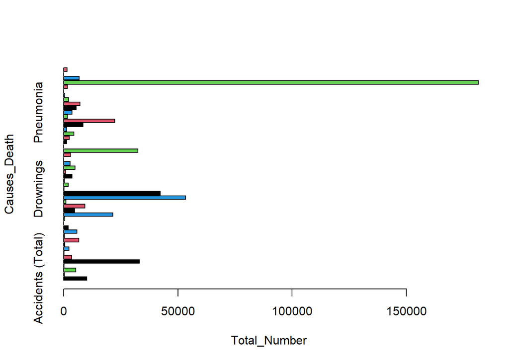

```r
barplot(Total_Number ~ Causes_Death, nyc_data,
        horiz = TRUE, col= 1:4)
```

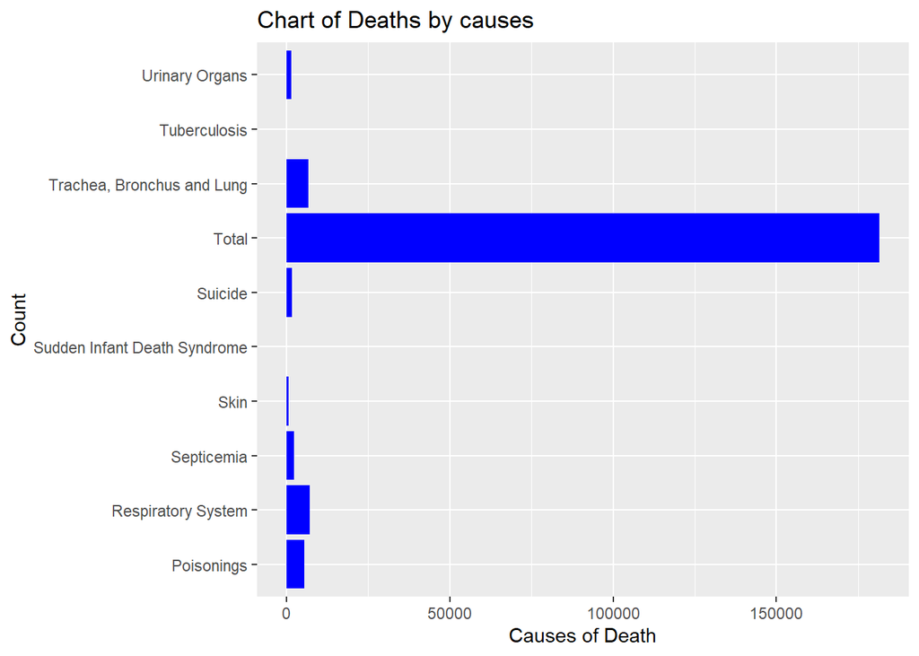

```r
nyc_data %>%
  top_n(10, Causes_Death) %>%
ggplot() + geom_bar(mapping = aes(x= Total_Number,y =Causes_Death), stat = "identity", position = "dodge", fill = "blue") +
  labs(title = "Chart of Deaths by causes", x= "Causes of Death" , y = "Count")
```

### Load second dataFrame from a csv file.

```r
nj_data<-read.csv("C:/Users/vitug/OneDrive/Desktop/DATA_607/NJ1.csv")
nj_data %>%
   kbl() %>%
  kable_styling(full_width = F)
```

| Causes.of.Death.in.Bergen.County.NJ | X | X.1 | X.2 | X.3 | X.4 | X.5 | X.6 | X.7 | X.8 | X.9 | X.10 | X.11 | X.12 | X.13 | X.14 | X.15 | X.16 | X.17 | X.18 | X.19 | X.20 | X.21 | X.22 | X.23 | X.24 | X.25 | X.26 | X.27 | X.28 | … |
| --- | --- | --- | --- | --- | --- | --- | --- | --- | --- | --- | --- | --- | --- | --- | --- | --- | --- | --- | --- | --- | --- | --- | --- | --- | --- | --- | --- | --- | --- | --- |
| Causes of death | year | male | famale | total | white | black | hispanic | asian | other | NA | NA | NA | NA | NA | NA | NA | NA | NA | NA | NA | NA | NA | NA | NA | NA | NA | NA | NA | NA | … |
|  |  |  |  |  |  |  |  |  |  | NA | NA | NA | NA | NA | NA | NA | NA | NA | NA | NA | NA | NA | NA | NA | NA | NA | NA | NA | NA | … |
| Enterocolitis due to Clostridium difficile (C. diff) | 2021 | 5 | 5 | 10 | 8 | 2 | NA | NA | NA | NA | NA | NA | NA | NA | NA | NA | NA | NA | NA | NA | NA | NA | NA | NA | NA | NA | NA | NA | NA | … |
| Septicemia | 2021 | 54 | 69 | 123 | 100 | 11 | 7 | 4 | 1 | NA | NA | NA | NA | NA | NA | NA | NA | NA | NA | NA | NA | NA | NA | NA | NA | NA | NA | NA | NA | … |
| Viral hepatitis | 2021 | 6 | NA | 6 | 3 | NA | 2 | 1 | NA | NA | NA | NA | NA | NA | NA | NA | NA | NA | NA | NA | NA | NA | NA | NA | NA | NA | NA | NA | NA | … |
| HIV (human immunodeficiency virus) disease | 2021 | 2 | 1 | 3 | NA | 1 | 2 | NA | NA | NA | NA | NA | NA | NA | NA | NA | NA | NA | NA | NA | NA | NA | NA | NA | NA | NA | NA | NA | NA | … |
| Coronavirus disease 2019 (COVID-19) | 2021 | 341 | 256 | 597 | 378 | 30 | 114 | 63 | 12 | NA | NA | NA | NA | NA | NA | NA | NA | NA | NA | NA | NA | NA | NA | NA | NA | NA | NA | NA | NA | … |
| Cancer (malignant neoplasms) | 2021 | 732 | 777 | 1,509 | 1163 | 47 | 149 | 128 | 22 | NA | NA | NA | NA | NA | NA | NA | NA | NA | NA | NA | NA | NA | NA | NA | NA | NA | NA | NA | NA | … |
| In situ neoplasms, benign neopl. & neopl. of uncertain or unknown behavior | 2021 | 27 | 22 | 49 | 38 | 2 | 3 | 6 | NA | NA | NA | NA | NA | NA | NA | NA | NA | NA | NA | NA | NA | NA | NA | NA | NA | NA | NA | NA | NA | … |
| Anemias | 2021 | 10 | 5 | 15 | 9 | 1 | 2 | 3 | NA | NA | NA | NA | NA | NA | NA | NA | NA | NA | NA | NA | NA | NA | NA | NA | NA | NA | NA | NA | NA | … |
| Diabetes mellitus | 2021 | 87 | 54 | 141 | 96 | 6 | 19 | 16 | 4 | NA | NA | NA | NA | NA | NA | NA | NA | NA | NA | NA | NA | NA | NA | NA | NA | NA | NA | NA | NA | … |
| Nutritional deficiencies | 2021 | 5 | 15 | 20 | 16 | NA | 1 | 3 | NA | NA | NA | NA | NA | NA | NA | NA | NA | NA | NA | NA | NA | NA | NA | NA | NA | NA | NA | NA | NA | … |
| Parkinson’s disease | 2021 | 60 | 35 | 95 | 79 | 1 | 9 | 5 | 1 | NA | NA | NA | NA | NA | NA | NA | NA | NA | NA | NA | NA | NA | NA | NA | NA | NA | NA | NA | NA | … |
| Alzheimer’s disease | 2021 | 74 | 200 | 274 | 223 | 9 | 29 | 11 | 2 | NA | NA | NA | NA | NA | NA | NA | NA | NA | NA | NA | NA | NA | NA | NA | NA | NA | NA | NA | NA | … |
| Diseases of heart | 2021 | 860 | 827 | 1,687 | 1354 | 86 | 132 | 93 | 22 | NA | NA | NA | NA | NA | NA | NA | NA | NA | NA | NA | NA | NA | NA | NA | NA | NA | NA | NA | NA | … |
| Essential hypertension and hypertensive renal disease | 2021 | 26 | 50 | 76 | 56 | 6 | 4 | 8 | 2 | NA | NA | NA | NA | NA | NA | NA | NA | NA | NA | NA | NA | NA | NA | NA | NA | NA | NA | NA | NA | … |
| Stroke (cerebrovascular diseases) | 2021 | 160 | 217 | 377 | 264 | 24 | 38 | NA | 9 | NA | NA | NA | NA | NA | NA | NA | NA | NA | NA | NA | NA | NA | NA | NA | NA | NA | NA | NA | NA | … |
| Atherosclerosis | 2021 | 2 | 3 | 5 | 5 | NA | NA | 42 | NA | NA | NA | NA | NA | NA | NA | NA | NA | NA | NA | NA | NA | NA | NA | NA | NA | NA | NA | NA | NA | … |
| Aortic aneurysm and dissection | 2021 | 12 | 8 | 20 | 16 | NA | 3 | 1 | NA | NA | NA | NA | NA | NA | NA | NA | NA | NA | NA | NA | NA | NA | NA | NA | NA | NA | NA | NA | NA | … |
| Influenza and pneumonia | 2021 | 56 | 38 | 94 | 72 | 5 | 6 | 7 | 4 | NA | NA | NA | NA | NA | NA | NA | NA | NA | NA | NA | NA | NA | NA | NA | NA | NA | NA | NA | NA | … |
| Chronic lower respiratory diseases (CLRD) | 2021 | 54 | 98 | 172 | 151 | 7 | 7 | 5 | 2 | NA | NA | NA | NA | NA | NA | NA | NA | NA | NA | NA | NA | NA | NA | NA | NA | NA | NA | NA | NA | … |
| Pneumonitis due to solids and liquids | 2021 | 37 | 45 | 82 | 66 | 1 | 2 | 11 | 2 | NA | NA | NA | NA | NA | NA | NA | NA | NA | NA | NA | NA | NA | NA | NA | NA | NA | NA | NA | NA | … |
| Chronic liver disease and cirrhosis | 2021 | 45 | 24 | 69 | 44 | 2 | 15 | 6 | 2 | NA | NA | NA | NA | NA | NA | NA | NA | NA | NA | NA | NA | NA | NA | NA | NA | NA | NA | NA | NA | … |
| Nephritis, nephrotic syndrome and nephrosis (kidney disease) | 2021 | 75 | 56 | 131 | 92 | 12 | 15 | 10 | 2 | NA | NA | NA | NA | NA | NA | NA | NA | NA | NA | NA | NA | NA | NA | NA | NA | NA | NA | NA | NA | … |
| Certain conditions originating in the perinatal period | 2021 | 7 | 4 | 11 | 7 | 1 | NA | 1 | 2 | NA | NA | NA | NA | NA | NA | NA | NA | NA | NA | NA | NA | NA | NA | NA | NA | NA | NA | NA | NA | … |
| Congenital malformations, deformations and chromosomal abnormalities (birth defects) | 2021 | 12 | 4 | 16 | 6 | 1 | 9 | NA | NA | NA | NA | NA | NA | NA | NA | NA | NA | NA | NA | NA | NA | NA | NA | NA | NA | NA | NA | NA | NA | … |
| Unintentional injuries | 2021 | 230 | 137 | 367 | 257 | 24 | 56 | 17 | 13 | NA | NA | NA | NA | NA | NA | NA | NA | NA | NA | NA | NA | NA | NA | NA | NA | NA | NA | NA | NA | … |
| Suicide (intentional self-harm) | 2021 | 47 | 12 | 59 | 36 | 1 | 9 | 9 | 4 | NA | NA | NA | NA | NA | NA | NA | NA | NA | NA | NA | NA | NA | NA | NA | NA | NA | NA | NA | NA | … |
| Homicide (assault) | 2021 | 6 | 8 | 14 | 3 | 1 | 7 | 2 | 1 | NA | NA | NA | NA | NA | NA | NA | NA | NA | NA | NA | NA | NA | NA | NA | NA | NA | NA | NA | NA | … |
| Complications of medical and surgical care | 2021 | 6 | 6 | 12 | 6 | 2 | 2 | 2 | NA | NA | NA | NA | NA | NA | NA | NA | NA | NA | NA | NA | NA | NA | NA | NA | NA | NA | NA | NA | NA | … |
| Other than 28 Major Causes | 2021 | 526 | 733 | 1,259 | 986 | 59 | 107 | 92 | 15 | NA | NA | NA | NA | NA | NA | NA | NA | NA | NA | NA | NA | NA | NA | NA | NA | NA | NA | NA | NA | … |
| Total |  |  |  | 7,293 | . |  |  |  |  | NA | NA | NA | NA | NA | NA | NA | NA | NA | NA | NA | NA | NA | NA | NA | NA | NA | NA | NA | NA | … |
|  |  |  |  |  |  |  |  |  |  | NA | NA | NA | NA | NA | NA | NA | NA | NA | NA | NA | NA | NA | NA | NA | NA | NA | NA | NA | NA | … |
|  |  |  |  |  |  |  |  |  |  | NA | NA | NA | NA | NA | NA | NA | NA | NA | NA | NA | NA | NA | NA | NA | NA | NA | NA | NA | NA | … |
|  |  |  |  |  |  |  |  |  |  | NA | NA | NA | NA | NA | NA | NA | NA | NA | NA | NA | NA | NA | NA | NA | NA | NA | NA | NA | NA | … |
|  |  |  |  |  |  |  |  |  |  | NA | NA | NA | NA | NA | NA | NA | NA | NA | NA | NA | NA | NA | NA | NA | NA | NA | NA | NA | NA | … |
|  |  |  |  |  |  |  |  |  |  | NA | NA | NA | NA | NA | NA | NA | NA | NA | NA | NA | NA | NA | NA | NA | NA | NA | NA | NA | NA | … |
|  |  |  |  |  |  |  |  |  |  | NA | NA | NA | NA | NA | NA | NA | NA | NA | NA | NA | NA | NA | NA | NA | NA | NA | NA | NA | NA | … |
|  |  |  |  |  |  |  |  |  |  | NA | NA | NA | NA | NA | NA | NA | NA | NA | NA | NA | NA | NA | NA | NA | NA | NA | NA | NA | NA | … |
|  |  |  |  |  |  |  |  |  |  | NA | NA | NA | NA | NA | NA | NA | NA | NA | NA | NA | NA | NA | NA | NA | NA | NA | NA | NA | NA | … |
|  |  |  |  |  |  |  |  |  |  | NA | NA | NA | NA | NA | NA | NA | NA | NA | NA | NA | NA | NA | NA | NA | NA | NA | NA | NA | NA | … |
|  |  |  |  |  |  |  |  |  |  | NA | NA | NA | NA | NA | NA | NA | NA | NA | NA | NA | NA | NA | NA | NA | NA | NA | NA | NA | NA | … |
|  |  |  |  |  |  |  |  |  |  | NA | NA | NA | NA | NA | NA | NA | NA | NA | NA | NA | NA | NA | NA | NA | NA | NA | NA | NA | NA | … |
|  |  |  |  |  |  |  |  |  |  | NA | NA | NA | NA | NA | NA | NA | NA | NA | NA | NA | NA | NA | NA | NA | NA | NA | NA | NA | NA | … |
|  |  |  |  |  |  |  |  |  |  | NA | NA | NA | NA | NA | NA | NA | NA | NA | NA | NA | NA | NA | NA | NA | NA | NA | NA | NA | NA | … |
|  |  |  |  |  |  |  |  |  |  | NA | NA | NA | NA | NA | NA | NA | NA | NA | NA | NA | NA | NA | NA | NA | NA | NA | NA | NA | NA | … |
|  |  |  |  |  |  |  |  |  |  | NA | NA | NA | NA | NA | NA | NA | NA | NA | NA | NA | NA | NA | NA | NA | NA | NA | NA | NA | NA | … |
|  |  |  |  |  |  |  |  |  |  | NA | NA | NA | NA | NA | NA | NA | NA | NA | NA | NA | NA | NA | NA | NA | NA | NA | NA | NA | NA | … |
|  |  |  |  |  |  |  |  |  |  | NA | NA | NA | NA | NA | NA | NA | NA | NA | NA | NA | NA | NA | NA | NA | NA | NA | NA | NA | NA | … |
|  |  |  |  |  |  |  |  |  |  | NA | NA | NA | NA | NA | NA | NA | NA | NA | NA | NA | NA | NA | NA | NA | NA | NA | NA | NA | NA | … |
|  |  |  |  |  |  |  |  |  |  | NA | NA | NA | NA | NA | NA | NA | NA | NA | NA | NA | NA | NA | NA | NA | NA | NA | NA | NA | NA | … |
|  |  |  |  |  |  |  |  |  |  | NA | NA | NA | NA | NA | NA | NA | NA | NA | NA | NA | NA | NA | NA | NA | NA | NA | NA | NA | NA | … |
|  |  |  |  |  |  |  |  |  |  | NA | NA | NA | NA | NA | NA | NA | NA | NA | NA | NA | NA | NA | NA | NA | NA | NA | NA | NA | NA | … |
|  |  |  |  |  |  |  |  |  |  | NA | NA | NA | NA | NA | NA | NA | NA | NA | NA | NA | NA | NA | NA | NA | NA | NA | NA | NA | NA | … |
|  |  |  |  |  |  |  |  |  |  | NA | NA | NA | NA | NA | NA | NA | NA | NA | NA | NA | NA | NA | NA | NA | NA | NA | NA | NA | NA | … |
|  |  |  |  |  |  |  |  |  |  | NA | NA | NA | NA | NA | NA | NA | NA | NA | NA | NA | NA | NA | NA | NA | NA | NA | NA | NA | NA | … |
|  |  |  |  |  |  |  |  |  |  | NA | NA | NA | NA | NA | NA | NA | NA | NA | NA | NA | NA | NA | NA | NA | NA | NA | NA | NA | NA | … |
|  |  |  |  |  |  |  |  |  |  | NA | NA | NA | NA | NA | NA | NA | NA | NA | NA | NA | NA | NA | NA | NA | NA | NA | NA | NA | NA | … |
|  |  |  |  |  |  |  |  |  |  | NA | NA | NA | NA | NA | NA | NA | NA | NA | NA | NA | NA | NA | NA | NA | NA | NA | NA | NA | NA | … |
|  |  |  |  |  |  |  |  |  |  | NA | NA | NA | NA | NA | NA | NA | NA | NA | NA | NA | NA | NA | NA | NA | NA | NA | NA | NA | NA | … |
|  |  |  |  |  |  |  |  |  |  | NA | NA | NA | NA | NA | NA | NA | NA | NA | NA | NA | NA | NA | NA | NA | NA | NA | NA | NA | NA | … |

### remove empty columns from dataset

```r
nj_data[ , c('X.9','X.10','X.11','X.12','X.13','X.14','X.15','X.16','X.17','X.18','X.19','X.20','X.21','X.22','X.23','X.24','X.25','X.26','X.27','X.28','X.29','X.30','X.31','X.32')] <- list(NULL)
nj_data %>%
 kbl() %>%
  kable_styling(full_width = F)
```

| Causes.of.Death.in.Bergen.County.NJ | X | X.1 | X.2 | X.3 | X.4 | X.5 | X.6 | X.7 | X.8 |
| --- | --- | --- | --- | --- | --- | --- | --- | --- | --- |
| Causes of death | year | male | famale | total | white | black | hispanic | asian | other |
| Enterocolitis due to Clostridium difficile (C. diff) | 2021 | 5 | 5 | 10 | 8 | 2 | NA | NA | NA |
| Septicemia | 2021 | 54 | 69 | 123 | 100 | 11 | 7 | 4 | 1 |
| Viral hepatitis | 2021 | 6 | NA | 6 | 3 | NA | 2 | 1 | NA |
| HIV (human immunodeficiency virus) disease | 2021 | 2 | 1 | 3 | NA | 1 | 2 | NA | NA |
| Coronavirus disease 2019 (COVID-19) | 2021 | 341 | 256 | 597 | 378 | 30 | 114 | 63 | 12 |
| Cancer (malignant neoplasms) | 2021 | 732 | 777 | 1,509 | 1163 | 47 | 149 | 128 | 22 |
| In situ neoplasms, benign neopl. & neopl. of uncertain or unknown behavior | 2021 | 27 | 22 | 49 | 38 | 2 | 3 | 6 | NA |
| Anemias | 2021 | 10 | 5 | 15 | 9 | 1 | 2 | 3 | NA |
| Diabetes mellitus | 2021 | 87 | 54 | 141 | 96 | 6 | 19 | 16 | 4 |
| Nutritional deficiencies | 2021 | 5 | 15 | 20 | 16 | NA | 1 | 3 | NA |
| Parkinson’s disease | 2021 | 60 | 35 | 95 | 79 | 1 | 9 | 5 | 1 |
| Alzheimer’s disease | 2021 | 74 | 200 | 274 | 223 | 9 | 29 | 11 | 2 |
| Diseases of heart | 2021 | 860 | 827 | 1,687 | 1354 | 86 | 132 | 93 | 22 |
| Essential hypertension and hypertensive renal disease | 2021 | 26 | 50 | 76 | 56 | 6 | 4 | 8 | 2 |
| Stroke (cerebrovascular diseases) | 2021 | 160 | 217 | 377 | 264 | 24 | 38 | NA | 9 |
| Atherosclerosis | 2021 | 2 | 3 | 5 | 5 | NA | NA | 42 | NA |
| Aortic aneurysm and dissection | 2021 | 12 | 8 | 20 | 16 | NA | 3 | 1 | NA |
| Influenza and pneumonia | 2021 | 56 | 38 | 94 | 72 | 5 | 6 | 7 | 4 |
| Chronic lower respiratory diseases (CLRD) | 2021 | 54 | 98 | 172 | 151 | 7 | 7 | 5 | 2 |
| Pneumonitis due to solids and liquids | 2021 | 37 | 45 | 82 | 66 | 1 | 2 | 11 | 2 |
| Chronic liver disease and cirrhosis | 2021 | 45 | 24 | 69 | 44 | 2 | 15 | 6 | 2 |
| Nephritis, nephrotic syndrome and nephrosis (kidney disease) | 2021 | 75 | 56 | 131 | 92 | 12 | 15 | 10 | 2 |
| Certain conditions originating in the perinatal period | 2021 | 7 | 4 | 11 | 7 | 1 | NA | 1 | 2 |
| Congenital malformations, deformations and chromosomal abnormalities (birth defects) | 2021 | 12 | 4 | 16 | 6 | 1 | 9 | NA | NA |
| Unintentional injuries | 2021 | 230 | 137 | 367 | 257 | 24 | 56 | 17 | 13 |
| Suicide (intentional self-harm) | 2021 | 47 | 12 | 59 | 36 | 1 | 9 | 9 | 4 |
| Homicide (assault) | 2021 | 6 | 8 | 14 | 3 | 1 | 7 | 2 | 1 |
| Complications of medical and surgical care | 2021 | 6 | 6 | 12 | 6 | 2 | 2 | 2 | NA |
| Other than 28 Major Causes | 2021 | 526 | 733 | 1,259 | 986 | 59 | 107 | 92 | 15 |
| Total |  |  |  | 7,293 | . |  |  |  |  |

### rename columns

```r
colnames(nj_data)[1] = "Causes_Death"
colnames(nj_data)[2] = "Year"
colnames(nj_data)[3] = "Male"
colnames(nj_data)[4] = "Female"
colnames(nj_data)[5] = "Total"
colnames(nj_data)[6] = "White"
colnames(nj_data)[7] = "Black"
colnames(nj_data)[8] = "Hispanic"
colnames(nj_data)[9] = "Asian"
colnames(nj_data)[10] = "Other"
nj_data %>%
   kbl() %>%
  kable_styling(full_width = F)
```

| Causes_Death | Year | Male | Female | Total | White | Black | Hispanic | Asian | Other |
| --- | --- | --- | --- | --- | --- | --- | --- | --- | --- |
| Causes of death | year | male | famale | total | white | black | hispanic | asian | other |
| Enterocolitis due to Clostridium difficile (C. diff) | 2021 | 5 | 5 | 10 | 8 | 2 | NA | NA | NA |
| Septicemia | 2021 | 54 | 69 | 123 | 100 | 11 | 7 | 4 | 1 |
| Viral hepatitis | 2021 | 6 | NA | 6 | 3 | NA | 2 | 1 | NA |
| HIV (human immunodeficiency virus) disease | 2021 | 2 | 1 | 3 | NA | 1 | 2 | NA | NA |
| Coronavirus disease 2019 (COVID-19) | 2021 | 341 | 256 | 597 | 378 | 30 | 114 | 63 | 12 |
| Cancer (malignant neoplasms) | 2021 | 732 | 777 | 1,509 | 1163 | 47 | 149 | 128 | 22 |
| In situ neoplasms, benign neopl. & neopl. of uncertain or unknown behavior | 2021 | 27 | 22 | 49 | 38 | 2 | 3 | 6 | NA |
| Anemias | 2021 | 10 | 5 | 15 | 9 | 1 | 2 | 3 | NA |
| Diabetes mellitus | 2021 | 87 | 54 | 141 | 96 | 6 | 19 | 16 | 4 |
| Nutritional deficiencies | 2021 | 5 | 15 | 20 | 16 | NA | 1 | 3 | NA |
| Parkinson’s disease | 2021 | 60 | 35 | 95 | 79 | 1 | 9 | 5 | 1 |
| Alzheimer’s disease | 2021 | 74 | 200 | 274 | 223 | 9 | 29 | 11 | 2 |
| Diseases of heart | 2021 | 860 | 827 | 1,687 | 1354 | 86 | 132 | 93 | 22 |
| Essential hypertension and hypertensive renal disease | 2021 | 26 | 50 | 76 | 56 | 6 | 4 | 8 | 2 |
| Stroke (cerebrovascular diseases) | 2021 | 160 | 217 | 377 | 264 | 24 | 38 | NA | 9 |
| Atherosclerosis | 2021 | 2 | 3 | 5 | 5 | NA | NA | 42 | NA |
| Aortic aneurysm and dissection | 2021 | 12 | 8 | 20 | 16 | NA | 3 | 1 | NA |
| Influenza and pneumonia | 2021 | 56 | 38 | 94 | 72 | 5 | 6 | 7 | 4 |
| Chronic lower respiratory diseases (CLRD) | 2021 | 54 | 98 | 172 | 151 | 7 | 7 | 5 | 2 |
| Pneumonitis due to solids and liquids | 2021 | 37 | 45 | 82 | 66 | 1 | 2 | 11 | 2 |
| Chronic liver disease and cirrhosis | 2021 | 45 | 24 | 69 | 44 | 2 | 15 | 6 | 2 |
| Nephritis, nephrotic syndrome and nephrosis (kidney disease) | 2021 | 75 | 56 | 131 | 92 | 12 | 15 | 10 | 2 |
| Certain conditions originating in the perinatal period | 2021 | 7 | 4 | 11 | 7 | 1 | NA | 1 | 2 |
| Congenital malformations, deformations and chromosomal abnormalities (birth defects) | 2021 | 12 | 4 | 16 | 6 | 1 | 9 | NA | NA |
| Unintentional injuries | 2021 | 230 | 137 | 367 | 257 | 24 | 56 | 17 | 13 |
| Suicide (intentional self-harm) | 2021 | 47 | 12 | 59 | 36 | 1 | 9 | 9 | 4 |
| Homicide (assault) | 2021 | 6 | 8 | 14 | 3 | 1 | 7 | 2 | 1 |
| Complications of medical and surgical care | 2021 | 6 | 6 | 12 | 6 | 2 | 2 | 2 | NA |
| Other than 28 Major Causes | 2021 | 526 | 733 | 1,259 | 986 | 59 | 107 | 92 | 15 |
| Total |  |  |  | 7,293 | . |  |  |  |  |

### Convert table to a DataFrame.

```r
nj_data <- as.data.frame(nj_data)
nj_data %>%
   kbl() %>%
  kable_styling(full_width = F)
```

| Causes_Death | Year | Male | Female | Total | White | Black | Hispanic | Asian | Other |
| --- | --- | --- | --- | --- | --- | --- | --- | --- | --- |
| Causes of death | year | male | famale | total | white | black | hispanic | asian | other |
| Enterocolitis due to Clostridium difficile (C. diff) | 2021 | 5 | 5 | 10 | 8 | 2 | NA | NA | NA |
| Septicemia | 2021 | 54 | 69 | 123 | 100 | 11 | 7 | 4 | 1 |
| Viral hepatitis | 2021 | 6 | NA | 6 | 3 | NA | 2 | 1 | NA |
| HIV (human immunodeficiency virus) disease | 2021 | 2 | 1 | 3 | NA | 1 | 2 | NA | NA |
| Coronavirus disease 2019 (COVID-19) | 2021 | 341 | 256 | 597 | 378 | 30 | 114 | 63 | 12 |
| Cancer (malignant neoplasms) | 2021 | 732 | 777 | 1,509 | 1163 | 47 | 149 | 128 | 22 |
| In situ neoplasms, benign neopl. & neopl. of uncertain or unknown behavior | 2021 | 27 | 22 | 49 | 38 | 2 | 3 | 6 | NA |
| Anemias | 2021 | 10 | 5 | 15 | 9 | 1 | 2 | 3 | NA |
| Diabetes mellitus | 2021 | 87 | 54 | 141 | 96 | 6 | 19 | 16 | 4 |
| Nutritional deficiencies | 2021 | 5 | 15 | 20 | 16 | NA | 1 | 3 | NA |
| Parkinson’s disease | 2021 | 60 | 35 | 95 | 79 | 1 | 9 | 5 | 1 |
| Alzheimer’s disease | 2021 | 74 | 200 | 274 | 223 | 9 | 29 | 11 | 2 |
| Diseases of heart | 2021 | 860 | 827 | 1,687 | 1354 | 86 | 132 | 93 | 22 |
| Essential hypertension and hypertensive renal disease | 2021 | 26 | 50 | 76 | 56 | 6 | 4 | 8 | 2 |
| Stroke (cerebrovascular diseases) | 2021 | 160 | 217 | 377 | 264 | 24 | 38 | NA | 9 |
| Atherosclerosis | 2021 | 2 | 3 | 5 | 5 | NA | NA | 42 | NA |
| Aortic aneurysm and dissection | 2021 | 12 | 8 | 20 | 16 | NA | 3 | 1 | NA |
| Influenza and pneumonia | 2021 | 56 | 38 | 94 | 72 | 5 | 6 | 7 | 4 |
| Chronic lower respiratory diseases (CLRD) | 2021 | 54 | 98 | 172 | 151 | 7 | 7 | 5 | 2 |
| Pneumonitis due to solids and liquids | 2021 | 37 | 45 | 82 | 66 | 1 | 2 | 11 | 2 |
| Chronic liver disease and cirrhosis | 2021 | 45 | 24 | 69 | 44 | 2 | 15 | 6 | 2 |
| Nephritis, nephrotic syndrome and nephrosis (kidney disease) | 2021 | 75 | 56 | 131 | 92 | 12 | 15 | 10 | 2 |
| Certain conditions originating in the perinatal period | 2021 | 7 | 4 | 11 | 7 | 1 | NA | 1 | 2 |
| Congenital malformations, deformations and chromosomal abnormalities (birth defects) | 2021 | 12 | 4 | 16 | 6 | 1 | 9 | NA | NA |
| Unintentional injuries | 2021 | 230 | 137 | 367 | 257 | 24 | 56 | 17 | 13 |
| Suicide (intentional self-harm) | 2021 | 47 | 12 | 59 | 36 | 1 | 9 | 9 | 4 |
| Homicide (assault) | 2021 | 6 | 8 | 14 | 3 | 1 | 7 | 2 | 1 |
| Complications of medical and surgical care | 2021 | 6 | 6 | 12 | 6 | 2 | 2 | 2 | NA |
| Other than 28 Major Causes | 2021 | 526 | 733 | 1,259 | 986 | 59 | 107 | 92 | 15 |
| Total |  |  |  | 7,293 | . |  |  |  |  |

### Remove row that contained names

```r
nj_data1<- nj_data[-c(1,2),]
nj_data %>%
   kbl() %>%
  kable_styling(full_width = F)
```

| Causes_Death | Year | Male | Female | Total | White | Black | Hispanic | Asian | Other |
| --- | --- | --- | --- | --- | --- | --- | --- | --- | --- |
| Causes of death | year | male | famale | total | white | black | hispanic | asian | other |
| Enterocolitis due to Clostridium difficile (C. diff) | 2021 | 5 | 5 | 10 | 8 | 2 | NA | NA | NA |
| Septicemia | 2021 | 54 | 69 | 123 | 100 | 11 | 7 | 4 | 1 |
| Viral hepatitis | 2021 | 6 | NA | 6 | 3 | NA | 2 | 1 | NA |
| HIV (human immunodeficiency virus) disease | 2021 | 2 | 1 | 3 | NA | 1 | 2 | NA | NA |
| Coronavirus disease 2019 (COVID-19) | 2021 | 341 | 256 | 597 | 378 | 30 | 114 | 63 | 12 |
| Cancer (malignant neoplasms) | 2021 | 732 | 777 | 1,509 | 1163 | 47 | 149 | 128 | 22 |
| In situ neoplasms, benign neopl. & neopl. of uncertain or unknown behavior | 2021 | 27 | 22 | 49 | 38 | 2 | 3 | 6 | NA |
| Anemias | 2021 | 10 | 5 | 15 | 9 | 1 | 2 | 3 | NA |
| Diabetes mellitus | 2021 | 87 | 54 | 141 | 96 | 6 | 19 | 16 | 4 |
| Nutritional deficiencies | 2021 | 5 | 15 | 20 | 16 | NA | 1 | 3 | NA |
| Parkinson’s disease | 2021 | 60 | 35 | 95 | 79 | 1 | 9 | 5 | 1 |
| Alzheimer’s disease | 2021 | 74 | 200 | 274 | 223 | 9 | 29 | 11 | 2 |
| Diseases of heart | 2021 | 860 | 827 | 1,687 | 1354 | 86 | 132 | 93 | 22 |
| Essential hypertension and hypertensive renal disease | 2021 | 26 | 50 | 76 | 56 | 6 | 4 | 8 | 2 |
| Stroke (cerebrovascular diseases) | 2021 | 160 | 217 | 377 | 264 | 24 | 38 | NA | 9 |
| Atherosclerosis | 2021 | 2 | 3 | 5 | 5 | NA | NA | 42 | NA |
| Aortic aneurysm and dissection | 2021 | 12 | 8 | 20 | 16 | NA | 3 | 1 | NA |
| Influenza and pneumonia | 2021 | 56 | 38 | 94 | 72 | 5 | 6 | 7 | 4 |
| Chronic lower respiratory diseases (CLRD) | 2021 | 54 | 98 | 172 | 151 | 7 | 7 | 5 | 2 |
| Pneumonitis due to solids and liquids | 2021 | 37 | 45 | 82 | 66 | 1 | 2 | 11 | 2 |
| Chronic liver disease and cirrhosis | 2021 | 45 | 24 | 69 | 44 | 2 | 15 | 6 | 2 |
| Nephritis, nephrotic syndrome and nephrosis (kidney disease) | 2021 | 75 | 56 | 131 | 92 | 12 | 15 | 10 | 2 |
| Certain conditions originating in the perinatal period | 2021 | 7 | 4 | 11 | 7 | 1 | NA | 1 | 2 |
| Congenital malformations, deformations and chromosomal abnormalities (birth defects) | 2021 | 12 | 4 | 16 | 6 | 1 | 9 | NA | NA |
| Unintentional injuries | 2021 | 230 | 137 | 367 | 257 | 24 | 56 | 17 | 13 |
| Suicide (intentional self-harm) | 2021 | 47 | 12 | 59 | 36 | 1 | 9 | 9 | 4 |
| Homicide (assault) | 2021 | 6 | 8 | 14 | 3 | 1 | 7 | 2 | 1 |
| Complications of medical and surgical care | 2021 | 6 | 6 | 12 | 6 | 2 | 2 | 2 | NA |
| Other than 28 Major Causes | 2021 | 526 | 733 | 1,259 | 986 | 59 | 107 | 92 | 15 |
| Total |  |  |  | 7,293 | . |  |  |  |  |

### Remove empty rows

```r
nj_data2 <- nj_data1[-c(30:61), ]
nj_data2 %>%
 kbl() %>%
  kable_styling(full_width = F)
```

|  | Causes_Death | Year | Male | Female | Total | White | Black | Hispanic | Asian | Other |
| --- | --- | --- | --- | --- | --- | --- | --- | --- | --- | --- |
| 3 | Enterocolitis due to Clostridium difficile (C. diff) | 2021 | 5 | 5 | 10 | 8 | 2 | NA | NA | NA |
| 4 | Septicemia | 2021 | 54 | 69 | 123 | 100 | 11 | 7 | 4 | 1 |
| 5 | Viral hepatitis | 2021 | 6 | NA | 6 | 3 | NA | 2 | 1 | NA |
| 6 | HIV (human immunodeficiency virus) disease | 2021 | 2 | 1 | 3 | NA | 1 | 2 | NA | NA |
| 7 | Coronavirus disease 2019 (COVID-19) | 2021 | 341 | 256 | 597 | 378 | 30 | 114 | 63 | 12 |
| 8 | Cancer (malignant neoplasms) | 2021 | 732 | 777 | 1,509 | 1163 | 47 | 149 | 128 | 22 |
| 9 | In situ neoplasms, benign neopl. & neopl. of uncertain or unknown behavior | 2021 | 27 | 22 | 49 | 38 | 2 | 3 | 6 | NA |
| 10 | Anemias | 2021 | 10 | 5 | 15 | 9 | 1 | 2 | 3 | NA |
| 11 | Diabetes mellitus | 2021 | 87 | 54 | 141 | 96 | 6 | 19 | 16 | 4 |
| 12 | Nutritional deficiencies | 2021 | 5 | 15 | 20 | 16 | NA | 1 | 3 | NA |
| 13 | Parkinson’s disease | 2021 | 60 | 35 | 95 | 79 | 1 | 9 | 5 | 1 |
| 14 | Alzheimer’s disease | 2021 | 74 | 200 | 274 | 223 | 9 | 29 | 11 | 2 |
| 15 | Diseases of heart | 2021 | 860 | 827 | 1,687 | 1354 | 86 | 132 | 93 | 22 |
| 16 | Essential hypertension and hypertensive renal disease | 2021 | 26 | 50 | 76 | 56 | 6 | 4 | 8 | 2 |
| 17 | Stroke (cerebrovascular diseases) | 2021 | 160 | 217 | 377 | 264 | 24 | 38 | NA | 9 |
| 18 | Atherosclerosis | 2021 | 2 | 3 | 5 | 5 | NA | NA | 42 | NA |
| 19 | Aortic aneurysm and dissection | 2021 | 12 | 8 | 20 | 16 | NA | 3 | 1 | NA |
| 20 | Influenza and pneumonia | 2021 | 56 | 38 | 94 | 72 | 5 | 6 | 7 | 4 |
| 21 | Chronic lower respiratory diseases (CLRD) | 2021 | 54 | 98 | 172 | 151 | 7 | 7 | 5 | 2 |
| 22 | Pneumonitis due to solids and liquids | 2021 | 37 | 45 | 82 | 66 | 1 | 2 | 11 | 2 |
| 23 | Chronic liver disease and cirrhosis | 2021 | 45 | 24 | 69 | 44 | 2 | 15 | 6 | 2 |
| 24 | Nephritis, nephrotic syndrome and nephrosis (kidney disease) | 2021 | 75 | 56 | 131 | 92 | 12 | 15 | 10 | 2 |
| 25 | Certain conditions originating in the perinatal period | 2021 | 7 | 4 | 11 | 7 | 1 | NA | 1 | 2 |
| 26 | Congenital malformations, deformations and chromosomal abnormalities (birth defects) | 2021 | 12 | 4 | 16 | 6 | 1 | 9 | NA | NA |
| 27 | Unintentional injuries | 2021 | 230 | 137 | 367 | 257 | 24 | 56 | 17 | 13 |
| 28 | Suicide (intentional self-harm) | 2021 | 47 | 12 | 59 | 36 | 1 | 9 | 9 | 4 |
| 29 | Homicide (assault) | 2021 | 6 | 8 | 14 | 3 | 1 | 7 | 2 | 1 |
| 30 | Complications of medical and surgical care | 2021 | 6 | 6 | 12 | 6 | 2 | 2 | 2 | NA |
| 31 | Other than 28 Major Causes | 2021 | 526 | 733 | 1,259 | 986 | 59 | 107 | 92 | 15 |

### Remove year column

```r
nj_data3 <- nj_data2[, -which(names(nj_data2) == "Year")]
nj_data3 %>%
   kbl() %>%
  kable_styling(full_width = F)
```

|  | Causes_Death | Male | Female | Total | White | Black | Hispanic | Asian | Other |
| --- | --- | --- | --- | --- | --- | --- | --- | --- | --- |
| 3 | Enterocolitis due to Clostridium difficile (C. diff) | 5 | 5 | 10 | 8 | 2 | NA | NA | NA |
| 4 | Septicemia | 54 | 69 | 123 | 100 | 11 | 7 | 4 | 1 |
| 5 | Viral hepatitis | 6 | NA | 6 | 3 | NA | 2 | 1 | NA |
| 6 | HIV (human immunodeficiency virus) disease | 2 | 1 | 3 | NA | 1 | 2 | NA | NA |
| 7 | Coronavirus disease 2019 (COVID-19) | 341 | 256 | 597 | 378 | 30 | 114 | 63 | 12 |
| 8 | Cancer (malignant neoplasms) | 732 | 777 | 1,509 | 1163 | 47 | 149 | 128 | 22 |
| 9 | In situ neoplasms, benign neopl. & neopl. of uncertain or unknown behavior | 27 | 22 | 49 | 38 | 2 | 3 | 6 | NA |
| 10 | Anemias | 10 | 5 | 15 | 9 | 1 | 2 | 3 | NA |
| 11 | Diabetes mellitus | 87 | 54 | 141 | 96 | 6 | 19 | 16 | 4 |
| 12 | Nutritional deficiencies | 5 | 15 | 20 | 16 | NA | 1 | 3 | NA |
| 13 | Parkinson’s disease | 60 | 35 | 95 | 79 | 1 | 9 | 5 | 1 |
| 14 | Alzheimer’s disease | 74 | 200 | 274 | 223 | 9 | 29 | 11 | 2 |
| 15 | Diseases of heart | 860 | 827 | 1,687 | 1354 | 86 | 132 | 93 | 22 |
| 16 | Essential hypertension and hypertensive renal disease | 26 | 50 | 76 | 56 | 6 | 4 | 8 | 2 |
| 17 | Stroke (cerebrovascular diseases) | 160 | 217 | 377 | 264 | 24 | 38 | NA | 9 |
| 18 | Atherosclerosis | 2 | 3 | 5 | 5 | NA | NA | 42 | NA |
| 19 | Aortic aneurysm and dissection | 12 | 8 | 20 | 16 | NA | 3 | 1 | NA |
| 20 | Influenza and pneumonia | 56 | 38 | 94 | 72 | 5 | 6 | 7 | 4 |
| 21 | Chronic lower respiratory diseases (CLRD) | 54 | 98 | 172 | 151 | 7 | 7 | 5 | 2 |
| 22 | Pneumonitis due to solids and liquids | 37 | 45 | 82 | 66 | 1 | 2 | 11 | 2 |
| 23 | Chronic liver disease and cirrhosis | 45 | 24 | 69 | 44 | 2 | 15 | 6 | 2 |
| 24 | Nephritis, nephrotic syndrome and nephrosis (kidney disease) | 75 | 56 | 131 | 92 | 12 | 15 | 10 | 2 |
| 25 | Certain conditions originating in the perinatal period | 7 | 4 | 11 | 7 | 1 | NA | 1 | 2 |
| 26 | Congenital malformations, deformations and chromosomal abnormalities (birth defects) | 12 | 4 | 16 | 6 | 1 | 9 | NA | NA |
| 27 | Unintentional injuries | 230 | 137 | 367 | 257 | 24 | 56 | 17 | 13 |
| 28 | Suicide (intentional self-harm) | 47 | 12 | 59 | 36 | 1 | 9 | 9 | 4 |
| 29 | Homicide (assault) | 6 | 8 | 14 | 3 | 1 | 7 | 2 | 1 |
| 30 | Complications of medical and surgical care | 6 | 6 | 12 | 6 | 2 | 2 | 2 | NA |
| 31 | Other than 28 Major Causes | 526 | 733 | 1,259 | 986 | 59 | 107 | 92 | 15 |

### Transform files from String to numeric.

```r
i <- c(2, 3, 4, 5, 6, 7, 8, 9)
nj_data3[, i] <- apply(nj_data3[, i], 2, function(x) as.numeric(as.character(x)))
sapply(nj_data3, class)
```

```
## Causes_Death         Male       Female        Total        White        Black
##  "character"    "numeric"    "numeric"    "numeric"    "numeric"    "numeric"
##     Hispanic        Asian        Other
##    "numeric"    "numeric"    "numeric"
```

```r
head(nj_data3)
```

```
##                                           Causes_Death Male Female Total White
## 3 Enterocolitis due to Clostridium difficile (C. diff)    5      5    10     8
## 4                                           Septicemia   54     69   123   100
## 5                                      Viral hepatitis    6     NA     6     3
## 6           HIV (human immunodeficiency virus) disease    2      1     3    NA
## 7                  Coronavirus disease 2019 (COVID-19)  341    256   597   378
## 8                         Cancer (malignant neoplasms)  732    777    NA  1163
##   Black Hispanic Asian Other
## 3     2       NA    NA    NA
## 4    11        7     4     1
## 5    NA        2     1    NA
## 6     1        2    NA    NA
## 7    30      114    63    12
## 8    47      149   128    22
```

### Replace NA values rows with zeros.

```r
nj_data3[is.na(nj_data3)] <- 0
nj_data3 %>%
 kbl() %>%
  kable_styling(full_width = F)
```

|  | Causes_Death | Male | Female | Total | White | Black | Hispanic | Asian | Other |
| --- | --- | --- | --- | --- | --- | --- | --- | --- | --- |
| 3 | Enterocolitis due to Clostridium difficile (C. diff) | 5 | 5 | 10 | 8 | 2 | 0 | 0 | 0 |
| 4 | Septicemia | 54 | 69 | 123 | 100 | 11 | 7 | 4 | 1 |
| 5 | Viral hepatitis | 6 | 0 | 6 | 3 | 0 | 2 | 1 | 0 |
| 6 | HIV (human immunodeficiency virus) disease | 2 | 1 | 3 | 0 | 1 | 2 | 0 | 0 |
| 7 | Coronavirus disease 2019 (COVID-19) | 341 | 256 | 597 | 378 | 30 | 114 | 63 | 12 |
| 8 | Cancer (malignant neoplasms) | 732 | 777 | 0 | 1163 | 47 | 149 | 128 | 22 |
| 9 | In situ neoplasms, benign neopl. & neopl. of uncertain or unknown behavior | 27 | 22 | 49 | 38 | 2 | 3 | 6 | 0 |
| 10 | Anemias | 10 | 5 | 15 | 9 | 1 | 2 | 3 | 0 |
| 11 | Diabetes mellitus | 87 | 54 | 141 | 96 | 6 | 19 | 16 | 4 |
| 12 | Nutritional deficiencies | 5 | 15 | 20 | 16 | 0 | 1 | 3 | 0 |
| 13 | Parkinson’s disease | 60 | 35 | 95 | 79 | 1 | 9 | 5 | 1 |
| 14 | Alzheimer’s disease | 74 | 200 | 274 | 223 | 9 | 29 | 11 | 2 |
| 15 | Diseases of heart | 860 | 827 | 0 | 1354 | 86 | 132 | 93 | 22 |
| 16 | Essential hypertension and hypertensive renal disease | 26 | 50 | 76 | 56 | 6 | 4 | 8 | 2 |
| 17 | Stroke (cerebrovascular diseases) | 160 | 217 | 377 | 264 | 24 | 38 | 0 | 9 |
| 18 | Atherosclerosis | 2 | 3 | 5 | 5 | 0 | 0 | 42 | 0 |
| 19 | Aortic aneurysm and dissection | 12 | 8 | 20 | 16 | 0 | 3 | 1 | 0 |
| 20 | Influenza and pneumonia | 56 | 38 | 94 | 72 | 5 | 6 | 7 | 4 |
| 21 | Chronic lower respiratory diseases (CLRD) | 54 | 98 | 172 | 151 | 7 | 7 | 5 | 2 |
| 22 | Pneumonitis due to solids and liquids | 37 | 45 | 82 | 66 | 1 | 2 | 11 | 2 |
| 23 | Chronic liver disease and cirrhosis | 45 | 24 | 69 | 44 | 2 | 15 | 6 | 2 |
| 24 | Nephritis, nephrotic syndrome and nephrosis (kidney disease) | 75 | 56 | 131 | 92 | 12 | 15 | 10 | 2 |
| 25 | Certain conditions originating in the perinatal period | 7 | 4 | 11 | 7 | 1 | 0 | 1 | 2 |
| 26 | Congenital malformations, deformations and chromosomal abnormalities (birth defects) | 12 | 4 | 16 | 6 | 1 | 9 | 0 | 0 |
| 27 | Unintentional injuries | 230 | 137 | 367 | 257 | 24 | 56 | 17 | 13 |
| 28 | Suicide (intentional self-harm) | 47 | 12 | 59 | 36 | 1 | 9 | 9 | 4 |
| 29 | Homicide (assault) | 6 | 8 | 14 | 3 | 1 | 7 | 2 | 1 |
| 30 | Complications of medical and surgical care | 6 | 6 | 12 | 6 | 2 | 2 | 2 | 0 |
| 31 | Other than 28 Major Causes | 526 | 733 | 0 | 986 | 59 | 107 | 92 | 15 |

### Create a total row with total sum of columns

```r
#add total row to data frame
nj_data4 <- nj_data3 %>%
            bind_rows(summarise(., across(where(is.numeric), sum),
                                   across(where(is.character), ~'Total')))

#view new data frame
tail(nj_data4)
```

```
##                                  Causes_Death Male Female Total White Black
## 25                     Unintentional injuries  230    137   367   257    24
## 26            Suicide (intentional self-harm)   47     12    59    36     1
## 27                         Homicide (assault)    6      8    14     3     1
## 28 Complications of medical and surgical care    6      6    12     6     2
## 29                 Other than 28 Major Causes  526    733     0   986    59
## 30                                      Total 3564   3709  2838  5534   342
##    Hispanic Asian Other
## 25       56    17    13
## 26        9     9     4
## 27        7     2     1
## 28        2     2     0
## 29      107    92    15
## 30      749   546   122
```

### Change data to Long Format

```r
nj_data5 <- nj_data4 %>% pivot_longer(cols=Total, names_to = "Total Deaths", values_to = "Total_Deaths")
nj_data5 %>%
   kbl() %>%
  kable_styling(full_width = F)
```

| Causes_Death | Male | Female | White | Black | Hispanic | Asian | Other | Total Deaths | Total_Deaths |
| --- | --- | --- | --- | --- | --- | --- | --- | --- | --- |
| Enterocolitis due to Clostridium difficile (C. diff) | 5 | 5 | 8 | 2 | 0 | 0 | 0 | Total | 10 |
| Septicemia | 54 | 69 | 100 | 11 | 7 | 4 | 1 | Total | 123 |
| Viral hepatitis | 6 | 0 | 3 | 0 | 2 | 1 | 0 | Total | 6 |
| HIV (human immunodeficiency virus) disease | 2 | 1 | 0 | 1 | 2 | 0 | 0 | Total | 3 |
| Coronavirus disease 2019 (COVID-19) | 341 | 256 | 378 | 30 | 114 | 63 | 12 | Total | 597 |
| Cancer (malignant neoplasms) | 732 | 777 | 1163 | 47 | 149 | 128 | 22 | Total | 0 |
| In situ neoplasms, benign neopl. & neopl. of uncertain or unknown behavior | 27 | 22 | 38 | 2 | 3 | 6 | 0 | Total | 49 |
| Anemias | 10 | 5 | 9 | 1 | 2 | 3 | 0 | Total | 15 |
| Diabetes mellitus | 87 | 54 | 96 | 6 | 19 | 16 | 4 | Total | 141 |
| Nutritional deficiencies | 5 | 15 | 16 | 0 | 1 | 3 | 0 | Total | 20 |
| Parkinson’s disease | 60 | 35 | 79 | 1 | 9 | 5 | 1 | Total | 95 |
| Alzheimer’s disease | 74 | 200 | 223 | 9 | 29 | 11 | 2 | Total | 274 |
| Diseases of heart | 860 | 827 | 1354 | 86 | 132 | 93 | 22 | Total | 0 |
| Essential hypertension and hypertensive renal disease | 26 | 50 | 56 | 6 | 4 | 8 | 2 | Total | 76 |
| Stroke (cerebrovascular diseases) | 160 | 217 | 264 | 24 | 38 | 0 | 9 | Total | 377 |
| Atherosclerosis | 2 | 3 | 5 | 0 | 0 | 42 | 0 | Total | 5 |
| Aortic aneurysm and dissection | 12 | 8 | 16 | 0 | 3 | 1 | 0 | Total | 20 |
| Influenza and pneumonia | 56 | 38 | 72 | 5 | 6 | 7 | 4 | Total | 94 |
| Chronic lower respiratory diseases (CLRD) | 54 | 98 | 151 | 7 | 7 | 5 | 2 | Total | 172 |
| Pneumonitis due to solids and liquids | 37 | 45 | 66 | 1 | 2 | 11 | 2 | Total | 82 |
| Chronic liver disease and cirrhosis | 45 | 24 | 44 | 2 | 15 | 6 | 2 | Total | 69 |
| Nephritis, nephrotic syndrome and nephrosis (kidney disease) | 75 | 56 | 92 | 12 | 15 | 10 | 2 | Total | 131 |
| Certain conditions originating in the perinatal period | 7 | 4 | 7 | 1 | 0 | 1 | 2 | Total | 11 |
| Congenital malformations, deformations and chromosomal abnormalities (birth defects) | 12 | 4 | 6 | 1 | 9 | 0 | 0 | Total | 16 |
| Unintentional injuries | 230 | 137 | 257 | 24 | 56 | 17 | 13 | Total | 367 |
| Suicide (intentional self-harm) | 47 | 12 | 36 | 1 | 9 | 9 | 4 | Total | 59 |
| Homicide (assault) | 6 | 8 | 3 | 1 | 7 | 2 | 1 | Total | 14 |
| Complications of medical and surgical care | 6 | 6 | 6 | 2 | 2 | 2 | 0 | Total | 12 |
| Other than 28 Major Causes | 526 | 733 | 986 | 59 | 107 | 92 | 15 | Total | 0 |
| Total | 3564 | 3709 | 5534 | 342 | 749 | 546 | 122 | Total | 2838 |

### Plot of main causes of death in NJ

```r
library(reshape2)
```

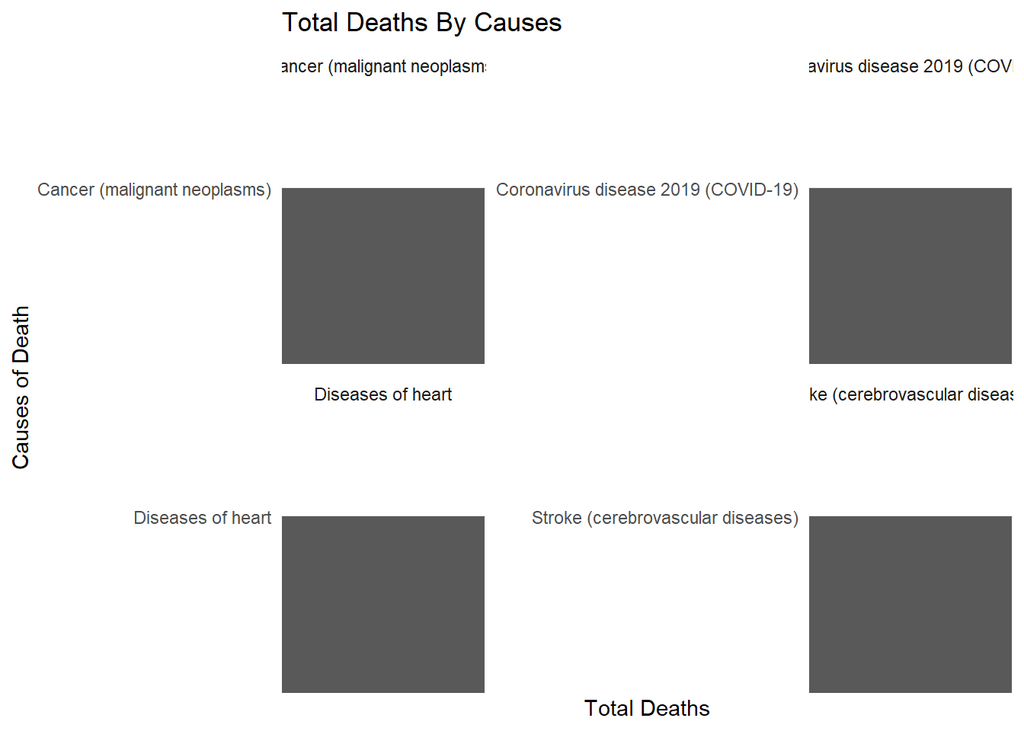

```r
nj_data5 |>
 filter( Causes_Death %in% c("Coronavirus disease 2019 (COVID-19)" ,"Cancer (malignant neoplasms)", "Diseases of heart", "Stroke (cerebrovascular diseases)")) |>
ggplot( aes(x= Total_Deaths,y = Causes_Death)) +
  geom_bar(stat = "identity", position = "dodge") +
  facet_wrap(~ Causes_Death, scales = "free") +
  theme_minimal() +
  theme(legend.position = "bottom") +
  scale_fill_brewer(palette = "Set3") +
  scale_x_discrete(breaks = unique(nj_data5$Total_Deaths)) +
labs(title = "Total Deaths By Causes", x= "Total Deaths" , y = "Causes of Death")
```

### Plot of male vs female deaths

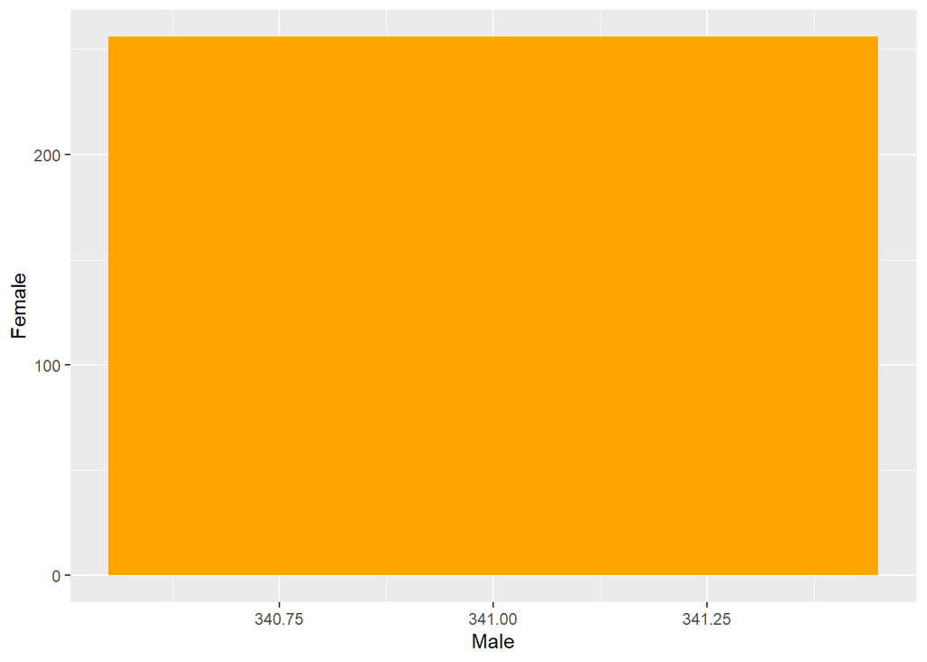

```r
nj_data6 <- nj_data5 %>%
  filter(nj_data5$Causes_Death == "Coronavirus disease 2019 (COVID-19)")

nj_data6 %>% ggplot(aes(x = Male, y = Female)) +
  geom_col(fill = "orange")
```

```r
  labs(title = "COVID 19 Deaths, Male vs Female", x = "Male", y = "Female")
```

```
## $x
## [1] "Male"
##
## $y
## [1] "Female"
##
## $title
## [1] "COVID 19 Deaths, Male vs Female"
##
## attr(,"class")
## [1] "labels"
```

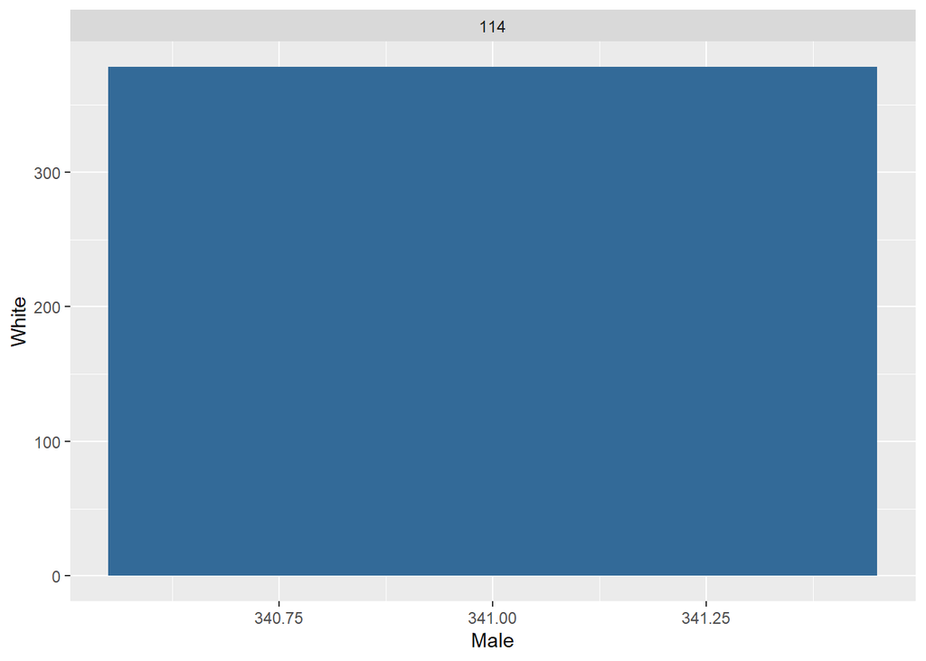

```r
ggplot(nj_data6, aes(Male, White, fill = Hispanic)) +
  geom_col(show.legend = FALSE) +
  facet_wrap(~Hispanic, ncol = 2, scales = "free_x")
```

### I am using the library arsenal to compare between the two databases, I found this tool very useful, and I never used it before.

```r
library(arsenal)
comparedf(nyc_data, nj_data5)
```

```
## Compare Object
##
## Function Call:
## comparedf(x = nyc_data, y = nj_data5)
##
## Shared: 1 non-by variables and 30 observations.
## Not shared: 18 variables and 21 observations.
##
## Differences found in 1/1 variables compared.
## 0 variables compared have non-identical attributes.
```

```r
summary(comparedf(nyc_data, nj_data5))
```

```
##
##
## Table: Summary of data.frames
##
## version   arg         ncol   nrow
## --------  ---------  -----  -----
## x         nyc_data      10     51
## y         nj_data5      10     30
##
##
##
## Table: Summary of overall comparison
##
## statistic                                                      value
## ------------------------------------------------------------  ------
## Number of by-variables                                             0
## Number of non-by variables in common                               1
## Number of variables compared                                       1
## Number of variables in x but not y                                 9
## Number of variables in y but not x                                 9
## Number of variables compared with some values unequal              1
## Number of variables compared with all values equal                 0
## Number of observations in common                                  30
## Number of observations in x but not y                             21
## Number of observations in y but not x                              0
## Number of observations with some compared variables unequal       30
## Number of observations with all compared variables equal           0
## Number of values unequal                                          30
##
##
##
## Table: Variables not shared
##
## version   variable               position  class
## --------  --------------------  ---------  ----------
## x         Total_Number                  2  numeric
## x         Crud_Rate                     3  numeric
## x         Adjusted_Rate                 4  numeric
## x         White_Total                   5  numeric
## x         White_Crude_Rate              6  numeric
```

[output cut: 69 more lines]

```
## Causes_Death   Causes_Death                5  Acquired Immune Deficiency Syndrome (AIDS)   Coronavirus disease 2019 (COVID-19)                                               5       5
## Causes_Death   Causes_Death                6  Malignant Neoplasms                          Cancer (malignant neoplasms)                                                      6       6
## Causes_Death   Causes_Death                7  Buccal Cavity and Pharynx                    In situ neoplasms, benign neopl. & neopl. of uncertain or unknown behavior        7       7
## Causes_Death   Causes_Death                8  Digestive Organs and Peritoneum              Anemias                                                                           8       8
## Causes_Death   Causes_Death                9  Respiratory System                           Diabetes mellitus                                                                 9       9
## Causes_Death   Causes_Death               10  Trachea, Bronchus and Lung                   Nutritional deficiencies                                                         10      10
##
##
##
## Table: Non-identical attributes
##
##
##  ----------------------------
##  No non-identical attributes
##  ----------------------------
```

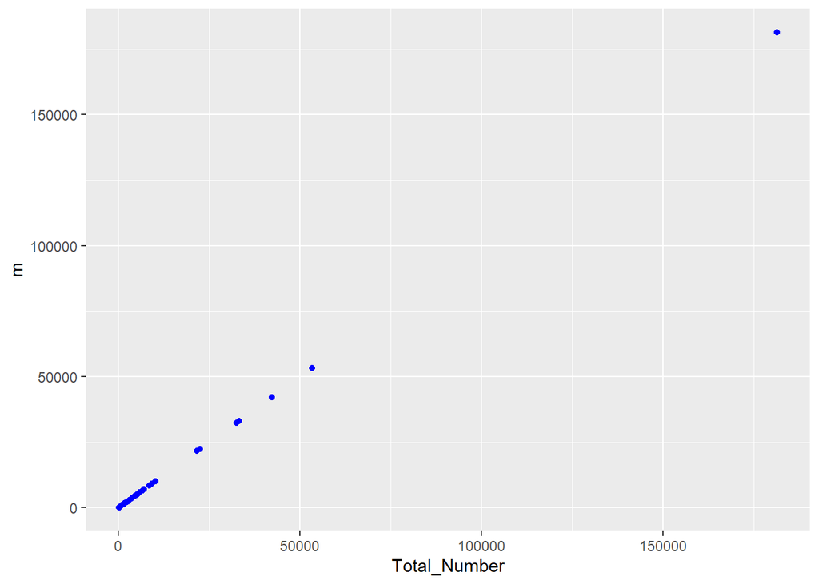

```r
nyc_plot <-
  nyc_data %>%
  group_by(Total_Number) %>%
summarize(m = mean(Total_Number))

nj_plot <-
  nj_data5 %>%
  group_by(Total_Deaths) %>%
  summarize(m = mean(Total_Deaths))

ggplot() +
  geom_point(data = nyc_plot, aes(x = Total_Number, y = m), color = "blue")
```

```r
  geom_point(data = nj_plot, aes(x = Total_Deaths, y = m))
```

```
## mapping: x = ~Total_Deaths, y = ~m
## geom_point: na.rm = FALSE
## stat_identity: na.rm = FALSE
## position_identity
```

### Violin plot of Causes of Death

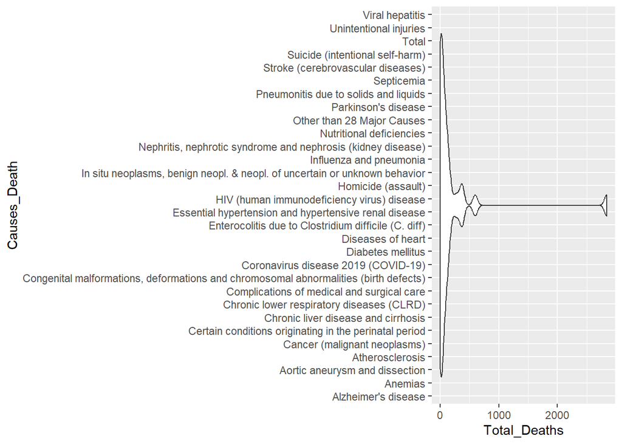

```r
nj_data5 %>%
  group_by(Causes_Death) %>%
  top_n(5, Causes_Death) %>%
  ggplot(aes(x = Total_Deaths, y = Causes_Death, group = 'Total Deaths', fill = Total_Deaths)) +
  geom_violin()
```

## Conclussion.

I was able to obtain data from two different sources (HTML table and a CSV file), I did scraped and clean the data in order to analyze it, The data needed it a lot of cleaning and tyding to start working on it. I did have some difficulties with the plots, I was not able to successfully create a clean, understandable plot, I am not sure if I did not organized the data correctly or maybe i am not inputting the correct code. I have to admit that I really enjoy this course, I believe that I learned a lot in the past few weeks, considering that I never used R before, I am proud to say I am on my way achieve my goals to become in a data scientist, I know that I have to still work on my skills, but I’m sure that with practice I will improve my knowledge.